# OPTED - WP5 Inventory of parliamentary text data sources

[OPTED WP5 team](https://cordis.europa.eu/project/id/951832/en) (2021-03-30 18:24:48)

# Purpose of this website

The project **[Observatory for Political Texts in European Democracies](https://cordis.europa.eu/project/id/951832/en)** (OPTED; Horizon 2020 Grant agreement 951832) aims to design a European Research Infrastructure facilitating the large-scale computational analysis of political texts in Europe.  
**Work Package 5** focuses on national and supranational parliaments. We cover textual data on political speeches and debates as well as legislative texts produced in and by these key institutions of European democracy.  
*Easier access to existing text data collections* as well as *identifying the gaps in extant data avilability* are among our key aims. Thus we have initially have assembled an **inventory of available text data sources** covering parliamentary activity. We identified the set of currently available sources - covering both primary archives and secondary data collections - by reviewing relevant academic literature, by scoping extant linguistic infrastructures (such as CLARIN), and by surveying the computational social science community via social media.  
This website navigates prospective users and analysts through the inventory. It firstly provides a bird’s eye view om the coverage of existing primary archives and secondary data collections. THis shows where additional investements in text data collection are needed in particular. It secondly provides interactive tables through which users can filter and jump to already available sources along their specific research needs. If you use any of these sources, please cite them appropriately.  
While we show all available sources we could uncover, we pay particular attention to what we call **‘ready-to-use’ data collections**. We label existing data collections as ready-to-use if the respective source provides:

- clearly separated raw texts (such as individual speeches or unique legislative bills, e.g.)
- basic meta-data for individual texts (such as dates or names and parties of speakers, e.g.)
- data formats easily accessible (importable with less than 10 lines of code) in common open-source software environments offering broad text analysis tools (such as R and Python in particular)

Users interested in **further detail** than provided here may also review the [full inventory](https://docs.google.com/spreadsheets/d/1QxDBwIcEFSBPK6ZcjGmi2VL9JGmtC5O_UfZ6Fcl3Lfo/gid=1192661106&fvid=1174920355), the respective [codebook](https://docs.google.com/document/d/16SnQC1rPHkk9UoESYi1Lfgu4qpFE23TxKHR_4FJt9ho/), or the [technical reports](https://drive.google.com/drive/u/0/folders/136lvH_ZN9zcgeemn5uZNkvNNgjl1XR7e) specifying the major primary and secondary sources per country or supranational institution.  
If a relevant data source or data collection is missing in your view, please do get in touch with the contributors below.

```r
# RMD author: Christian Rauh (24.02.2021)

# Packages ####
library(tidyverse)
library(gsheet)
library(countrycode)
require(rworldmap)
require(mapproj)
require(viridis)
require(cowplot)
library(patchwork)
library(reactable)


# # Extract data from common google sheet ####
# # Depends on formatting decisions there, cross check whenever the analysis is repeated!
# # Latest: February 24 2021, 2 pm
#
# # Speech Inventory
# speeches <- as.data.frame(gsheet2tbl('https://docs.google.com/spreadsheets/d/1QxDBwIcEFSBPK6ZcjGmi2VL9JGmtC5O_UfZ6Fcl3Lfo/gid=620510387'))
# speeches <- speeches[,-1] # Drop first column, empty
# names(speeches) <- speeches[5,] # the technical header
# speeches <- speeches[6:nrow(speeches), ] # Remove non-technical header
#
# speeches <- speeches %>%
#   select(-c(api, text.type, init.source, meta.vars, copyright.owner, comment, notes,
#             gender.av, leader.av, smd.av, codebook.av, database.id)) %>%
#   na_if("-") %>%
#   na_if("99") %>%
#   na_if("N/A")
#
#
# speeches$region <- speeches$region %>%
#   as.numeric() %>%
#   recode(`1` = "Central East Europe",
#          `2` = "Northern Europe",
#          `3` = "Southern Europe",
#          `4` = "Western Europe",
#          `5` = "Supranational",
#          `6` = "Other")
#
# speeches$start.date <- speeches$start.date %>% as.numeric()
# speeches$end.date <- speeches$end.date %>%
#   recode("up to date" = "2021") %>%
#   as.numeric()
#
# speeches$texttypes <- ""
# speeches$texttypes <- ifelse(speeches$plenary.speeches == 1, paste0(speeches$texttypes, "Plenary speeches"), speeches$texttypes)
# speeches$texttypes <- ifelse(speeches$questions == 1, paste0(speeches$texttypes, ", Questions"), speeches$texttypes)
# speeches$texttypes <- ifelse(speeches$interpellations == 1, paste0(speeches$texttypes, ", Interpellations"), speeches$texttypes)
# speeches$texttypes <- str_remove(speeches$texttypes, "^, ")
# speeches$texttypes <- ifelse(speeches$texttypes == "", "Other speech texts", speeches$texttypes)
# table(speeches$texttypes)
#
# speeches$iso3 <-  countrycode(speeches$country, origin = "country.name", "iso3c")
#
# speeches$ready <- as.logical(as.numeric(speeches$importable.metadata))
# speeches$ready[is.na(speeches$ready)] <- F # What are these?
# table(speeches$ready, useNA = "ifany")
#
# # Law texts
# laws <- as.data.frame(gsheet2tbl('https://docs.google.com/spreadsheets/d/1QxDBwIcEFSBPK6ZcjGmi2VL9JGmtC5O_UfZ6Fcl3Lfo/gid=1192661106&fvid=1174920355'))
# names(laws) <- laws[5,] # the technical header
# laws <- laws[6:nrow(laws), -1] # Remove non-technical header
#
# laws <- laws %>%
#   select(-c(api, text.type, init.source, meta.vars, copyright.owner, comment, notes,
#             gender.av, leader.av, smd.av, codebook.av)) %>%
#   na_if("-") %>%
#   na_if("99") %>%
#   na_if("N/A")
#
#
# laws$region <- laws$region %>%
#   as.numeric() %>%
#   recode(`1` = "Central East Europe",
#          `2` = "Northern Europe",
#          `3` = "Southern Europe",
#          `4` = "Western Europe",
#          `5` = "Supranational",
#          `6` = "Other")
# table(laws$region)
#
# laws$start.date <- laws$start.date %>% as.numeric()
# laws$end.date <- laws$end.date %>%
#   recode("up to date" = "2021") %>%
#   as.numeric()
#
# laws$texttypes <- ""
# laws$texttypes <- ifelse(laws$laws == 1, paste0(laws$texttypes, "Laws"), laws$texttypes)
# laws$texttypes <- ifelse(laws$bills == 1, paste0(laws$texttypes, ", Bills"), laws$texttypes)
# laws$texttypes <- ifelse(laws$amendments == 1, paste0(laws$texttypes, ", Amendments"), laws$texttypes)
# laws$texttypes <- ifelse(!is.na(laws$other), paste0(laws$texttypes, ", Other legal text"), laws$texttypes)
# laws$texttypes <- str_remove(laws$texttypes, "^, ")
# table(laws$texttypes)
#
# laws$iso3 <-  countrycode(laws$country, origin = "country.name", "iso3c")
#
# laws$ready <- as.logical(as.numeric(laws$importable.metadata))
# laws$ready[is.na(laws$ready)] <- F # What are these?
# table(laws$ready, useNA = "ifany")
#
# # Store contemporary version locally
# write_rds(speeches, "./Data/Speeches_20210330.rds")
# write_rds(laws, "./Data/Laws_20210330.rds")

speeches <- read_rds("./Data/Speeches_20210330.rds")
laws <- read_rds("./Data/Laws_20210330.rds")
```

# A bird’s eye view on available parliamentary text data

## Types of parliamentary texts

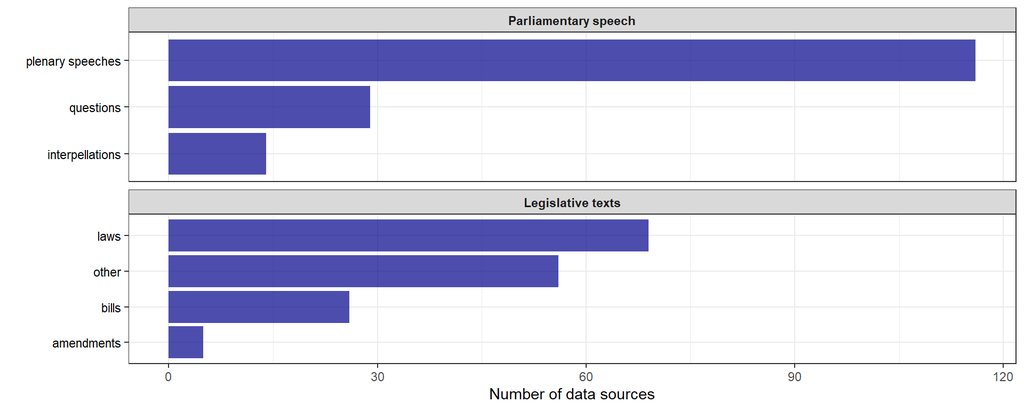

```r
stypes <- speeches %>%
  select(c(plenary.speeches, questions, interpellations)) %>%
  mutate(across(everything(), as.numeric)) %>%
  colSums(na.rm = T) %>%
  data.frame() %>%
  rename(count = 1) %>%
  rownames_to_column() %>%
  rename(type = rowname) %>%
  mutate(type = str_replace(type, fixed("."), " ")) %>%
  mutate(category = "Parliamentary speech")

ltypes <- laws %>%
  select(c(laws, bills, amendments, other)) %>%
  mutate(other = ifelse(is.na(other), 0, 1)) %>%
  mutate(across(everything(), as.numeric)) %>%
  colSums(na.rm = T) %>%
  data.frame() %>%
  rename(count = 1) %>%
  rownames_to_column() %>%
  rename(type = rowname) %>%
  mutate(type = str_replace(type, fixed("."), "")) %>%
  mutate(category = "Legislative texts")

types <- rbind(stypes, ltypes) %>%
  mutate(category = factor(category, levels = c("Parliamentary speech", "Legislative texts")))

ggplot(types, aes(y= reorder(type,count), x=count)) +
  geom_col(fill = "darkblue", alpha = .7)+
  facet_wrap(.~category, nrow = 2, scales = "free_y")+
  labs(y= "", x= "Number of data sources")+
  theme_bw()+
  theme(strip.text.x = element_text(face = "bold"),
        axis.text.y = element_text(color = "black"))
```

With regard to *speeches of and debates* among MPs (and the government) the **most frequently available text data type are full text transcriptions of plenary speeches**. More specific debate types (such as parliamentary questions) are often nested within plenary debates (depending on the organisation of the respective parliament and/or its archive) and must be extracted separately. Dedicated data sources and/or collections for such speech types are only rarely available thus far.  
With regard to *legislative text*, primarily the **finally adopted laws** are available (in many primary sources also limited to laws currently in force). Information on the intermediary stages of legislative decision-making - in particular with a view to bills and amendments - are much less frequently available thus far.

## Geographical coverage

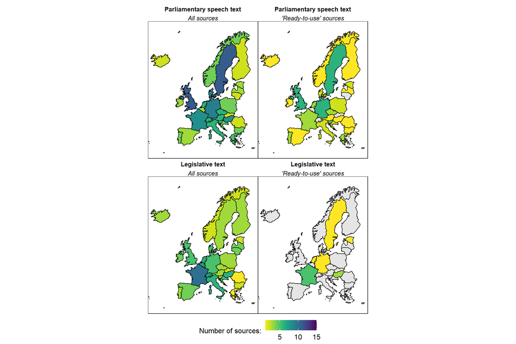

```r
# Get EU28+ map and ISOs ####
wmap <- getMap(resolution = "low") # Worldmap
EU28 <- c("Austria","Belgium","Bulgaria","Croatia","Cyprus", # Vector of EU 28 countries + EFTA + Eastern Neighbours
          "Czech Rep.","Denmark","Estonia","Finland","France",
          "Germany","Greece","Hungary","Ireland","Italy","Latvia",
          "Lithuania","Luxembourg","Malta","Netherlands","Poland",
          "Portugal","Romania","Slovakia","Slovenia","Spain",
          "Sweden","United Kingdom", "Norway", "Switzerland", "Liechtenstein",
          "Iceland")
indEU <- which(wmap$NAME%in%EU28)# Select only the index of EU 28 in wmap
eumap <- lapply(indEU, function(i){ # Select polygons along EU28 index
  df <- data.frame(wmap@polygons[[i]]@Polygons[[1]]@coords)
  df$region <- as.character(wmap$NAME[i])
  df$id <- as.character(wmap$ISO_A3[i])
  colnames(df) <- list("long", "lat", "region", "id")
  return(df)})
eumap <- do.call("rbind", eumap) # Bild Europe map
eu28_iso <- unique(eumap$id) # Extract iso country codes


# Get counts of text category data sets by country (iso3) ####
speeches.total <- speeches %>%
  group_by(iso3) %>%
  summarise(stotal.count = n())
speeches.ready <- speeches %>%  filter(ready == T) %>%
  group_by(iso3) %>%
  summarise(sready.count = n())
laws.total <- laws %>%
  group_by(iso3) %>%
  summarise(ltotal.count = n())
laws.ready <- laws %>%  filter(ready == T) %>%
  group_by(iso3) %>%
  summarise(lready.count = n())

# Get maximum range of counts
cmax <- max(c(speeches.total$stotal.count, laws.total$ltotal.count))
cmin <- min(c(speeches.total$stotal.count, laws.total$ltotal.count))

# Join country count data with the world map ####

wmap_df <- fortify(wmap, region = "ISO3")
wmap_df <- wmap_df[wmap_df$id %in% eu28_iso, ]

wmap_df <- left_join(wmap_df, speeches.total, by = c('id'='iso3'))
wmap_df <- left_join(wmap_df, speeches.ready, by = c('id'='iso3'))
wmap_df <- left_join(wmap_df, laws.total, by = c('id'='iso3'))
wmap_df <- left_join(wmap_df, laws.ready, by = c('id'='iso3'))

# Individual plots
pl.speeches.total <-
  ggplot(data=wmap_df) +
  geom_polygon(aes(x = long, y = lat, fill=stotal.count, group = group), color="black") +
  scale_fill_viridis(name="Number of sources:", begin = 1, end = 0, limits = c(cmin,cmax), na.value="gray90") +
  theme_void() +
  labs(title = "Parliamentary speech text",
       subtitle = "All sources") +
  coord_map(xlim = c(-23, 33),  ylim = c(32, 70.9))+
  theme( plot.title = element_text(hjust = 0.5, vjust = 1, size=10, face = "bold"),
         plot.subtitle = element_text(hjust = 0.5, vjust = 1, size=10, face = "italic"),
         legend.position = "bottom",
         legend.title=element_text(size=12),
         legend.text=element_text(size=12),
         panel.border = element_rect(colour = "black", fill = NA),
         plot.margin = unit(c(0, 0, 0, 0), "cm"))
pl.speeches.ready <-
  ggplot(data=wmap_df) +
  geom_polygon(aes(x = long, y = lat, fill=sready.count, group = group), color="black") +
  scale_fill_viridis(name="Number of sources:", begin = 1, end = 0, limits = c(cmin,cmax), na.value="gray90") +
  theme_void() +
  labs(title = "Parliamentary speech text",
       subtitle = "\'Ready-to-use\' sources") +
  coord_map(xlim = c(-23, 33),  ylim = c(32, 70.9))+
  theme( plot.title = element_text(hjust = 0.5, vjust = 1, size=10, face = "bold"),
         plot.subtitle = element_text(hjust = 0.5, vjust = 1, size=10, face = "italic"),
         legend.position = "none",
         legend.title=element_text(size=12),
         legend.text=element_text(size=12),
         panel.border = element_rect(colour = "black", fill = NA),
         plot.margin = unit(c(0, 0, 0, 0), "cm"))
pl.laws.total <-
  ggplot(data=wmap_df) +
  geom_polygon(aes(x = long, y = lat, fill=ltotal.count, group = group), color="black") +
  scale_fill_viridis(name="Number of sources:", begin = 1, end = 0, limits = c(cmin,cmax), na.value="gray90") +
  theme_void() +
  labs(title = "Legislative text",
       subtitle = "All sources") +
  coord_map(xlim = c(-23, 33),  ylim = c(32, 70.9))+
  theme( plot.title = element_text(hjust = 0.5, vjust = 1, size=10, face = "bold"),
         plot.subtitle = element_text(hjust = 0.5, vjust = 1, size=10, face = "italic"),
         legend.position = "none",
         legend.title=element_text(size=12),
         legend.text=element_text(size=12),
         panel.border = element_rect(colour = "black", fill = NA),
         plot.margin = unit(c(0, 0, 0, 0), "cm"))
pl.laws.ready <-
  ggplot(data=wmap_df) +
  geom_polygon(aes(x = long, y = lat, fill=lready.count, group = group), color="black") +
  scale_fill_viridis(name="Number of sources:", begin = 1, end = 0, limits = c(cmin,cmax), na.value="gray90") +
  theme_void() +
  labs(title = "Legislative text",
       subtitle = "\'Ready-to-use\' sources") +
  coord_map(xlim = c(-23, 33),  ylim = c(32, 70.9))+
  theme( plot.title = element_text(hjust = 0.5, vjust = 1, size=10, face = "bold"),
         plot.subtitle = element_text(hjust = 0.5, vjust = 1, size=10, face = "italic"),
         legend.position = "none",
         legend.title=element_text(size=12),
         legend.text=element_text(size=12),
         panel.border = element_rect(colour = "black", fill = NA),
         plot.margin = unit(c(0, 0, 0, 0), "cm"))

# Combine and export plots
p <- pl.speeches.total + pl.speeches.ready + pl.laws.total + pl.laws.ready +
  plot_layout(guides = 'collect') & theme(legend.position = 'bottom')
p
```

Comparing the left and the right panel of the plot one immediately sees that **many primary sources of parliamentary text data have not been transferred to ‘ready-to-use’ data sets** that would be easily amenable to automated text analysis. Especially where comparatively well-structured primary sources exist, additional data collection efforts appear to be a low hanging fruit.  
We also see that the **availability of ‘ready-to-use’ data is particularly scant for legislative texts.** Given that negotiating and fixing collectively binding rules are a key purpose of parliaments in democratic states, we thus far can hardly exploit the power of text-as-data aproaches for these processes.  
We also see **striking geographical imbalances**: Some countries such as Germany and France are covered by various sources already, whereas systematic data on Central and Eastern European countries is much more scarce.  
In adddition, there are **no ‘ready-to-use’ text data collections combining multiple countries**, with ParlSpeech being the only exception.

```r
# Check for multi-country, ready-to-use
lsourc <- laws %>% select(source.name, country, ready)
lsourc$dupl <- duplicated(lsourc) # Duplicates: same source, same country, but proabaly different text types

lsourc <- lsourc %>% filter(!dupl) %>%
  group_by(source.name) %>%
  summarise(countries = paste(country, collapse =", "),
            ready = mean(ready, na.rm =T)) %>%
  mutate(c.cover = str_count(countries, ",")) %>%
  arrange(desc(c.cover))

# lsourc$multi <- ifelse(lsourc$ready == 1 & lsourc$c.cover > 0, T, F)
# lsourc$source.name[lsourc$multi]

ssourc <- speeches %>% select(source.name, country, ready)
ssourc$dupl <- duplicated(ssourc) # Duplicates: same source, same country, but proabaly different text types

ssourc <- ssourc %>% filter(!dupl) %>%
  group_by(source.name) %>%
  summarise(countries = paste(country, collapse =", "),
            ready = mean(ready, na.rm =T)) %>%
  mutate(c.cover = str_count(countries, ",")) %>%
  arrange(desc(c.cover))

# ssourc$multi <- ifelse(ssourc$ready == 1 & ssourc$c.cover > 0, T, F)
# ssourc$source.name[ssourc$multi]

# There are none, except ParlSpeech ...
```

## Temporal coverage of ‘ready-to-use’ sources

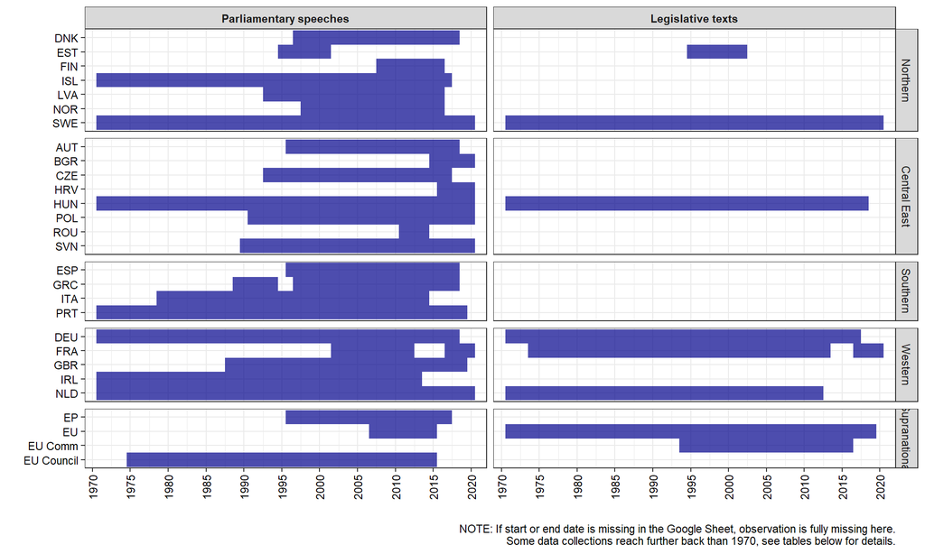

```r
# Sequence of covered years by country
# NOTE: many missing in start and end date

speeches$iso3[speeches$country == "European Parliament"] <- "EP"
speeches$iso3[speeches$country == "European Commission"] <- "EU Comm"
speeches$iso3[speeches$country == "European Council"] <- "EU Council"
speeches$iso3[speeches$country == "Council of the European Union"] <- "EU Council"
speeches$iso3[speeches$country == "European Union"] <- "EU"

speech.years <- speeches %>%
  filter(ready == T) %>%
  filter(!is.na(start.date) & !is.na(end.date)) %>% # Check these in the source file !
  rowwise() %>%
  do(data.frame(iso3=.$iso3, years=seq(.$start.date,.$end.date,by=1))) %>%
  unique() %>% #Unique observations, duplicates when dataset ranges overlap
  mutate(av = T) %>% # Indicator that the year is present
  mutate(category = "Parliamentary speeches")

laws$iso3[laws$country == "European Parliament"] <- "EP"
laws$iso3[laws$country == "European Commission"] <- "EU Comm"
laws$iso3[laws$country == "European Council"] <- "EU Council"
laws$iso3[laws$country == "Council of the European Union"] <- "EU Council"
laws$iso3[laws$country == "European Union"] <- "EU"

law.years <- laws %>%
  filter(ready == T) %>%
  filter(!is.na(start.date) & !is.na(end.date)) %>% # Check these in the source file !
  rowwise() %>%
  do(data.frame(iso3=.$iso3, years=seq(.$start.date,.$end.date,by=1))) %>%
  unique() %>% #Unique observations, duplicates when dataset ranges overlap
  mutate(av = T) %>% # Indicator that the year is present
  mutate(category = "Legislative texts")

coverage <- rbind(speech.years, law.years)

# Add region ####
speeches$region <- str_replace(speeches$region, "Nothern", "Northern")
cregion <- rbind(speeches %>%  select(c("iso3", "region")),
                 laws %>%  select(c("iso3", "region"))) %>%
  unique()
# length(unique(cregion$country)) == nrow(cregion) # Cross-check
# table(cregion$region)

coverage <- merge(coverage, cregion, all.x = T)

# Plot coverage ####

# Plot orders
coverage$category <- factor(coverage$category, levels = c("Parliamentary speeches", "Legislative texts"))
coverage$region <- coverage$region %>% str_remove(" Europe") %>% factor(levels = c("Northern", "Central East", "Southern", "Western", "Other", "Supranational"))
coverage$country <- coverage$iso3 %>% factor(levels = sort(unique(coverage$iso3), decreasing = T))

# Heatmap
ggplot(coverage, aes(x=years, y= country))+
  geom_tile(color = NA, fill = "darkblue", alpha = .7)+
  # coord_cartesian(xlim = c(1900, 2020))+
  scale_x_continuous(limits = c(1970, 2021), breaks = seq(1970,2020, 5), expand = c(0.02,0.02))+
  # facet_wrap(~ region, ncol = 1, scales = "free_y", drop = F)+
  facet_grid(region ~ category, scales = "free_y", space = "free_y")+
  labs(x="", y="",
      # title = "Temporal coverage of \'ready-to-use\' text data collections\non parliamentary activity in Europe",
       caption = "NOTE: If start or end date is missing in the Google Sheet, observation is fully missing here.\nSome data collections reach further back than 1970, see tables below for details.")+
  theme_bw()+
  theme(axis.text = element_text(colour = "black"),
        axis.text.x = element_text(angle = 90, vjust = .5),
        strip.text.x = element_text(face = "bold"),
        plot.title = element_text(hjust = 0.5, vjust = 1, size=15))
```

# Find your data source: Parliamentary speeches

```r
sout <- speeches %>%
  select(c(country, source.name, primary, texttypes, start.date, end.date, coverage, ready, source.link)) %>%
  mutate(country.report = "https://drive.google.com/drive/u/0/folders/136lvH_ZN9zcgeemn5uZNkvNNgjl1XR7e")

sout$coverage[is.na(sout$coverage)] <- 0 # Cross-check
sout$coverage <- ifelse(sout$coverage == 1, T, F)
sout$primary <- ifelse(sout$primary == 1, "Primary", "Secondary")

reactable(sout[, -c(2,10)], defaultSorted = "country",
          pagination = F,
          bordered = T,
          highlight = TRUE,
          wrap = F,
          resizable = TRUE,
          height = 300,
          showSortIcon = T,
          filterable = TRUE,
          minRows = 0,
          columns = list(
            country = colDef(name = "Country"),
            texttypes = colDef(name = "Text types"),
            primary = colDef(name = "Archive type", align = "center"),
            # texttypes = colDef(name = "Text types"),
            start.date = colDef(name = "Start Year", align = "center"),
            end.date = colDef(name = "End Year", align = "center"),
            coverage = colDef(name = "Full coverage?", align = "center",
                           cell = function(value) {
    # Render as ✘ or ✓
    if (value == FALSE) "\u2718" else "\u2713"
  }),
            ready = colDef(name = "Ready to use?", align = "center",
                           cell = function(value) {
    # Render as ✘ or ✓
    if (value == FALSE) "\u2718" else "\u2713"
  }),
  source.link = colDef(cell = function(value) {
    # Render as a link
    htmltools::tags$a(href = value, target = "_blank", as.character("Click"))
  }, name = "Access source", align = "center")
  # country.report = colDef(cell = function(value) {
  #   # Render as a link
  #   htmltools::tags$a(href = value, target = "_blank", as.character("Link"))
  # }, name = "Country Report")
  ),
          details = function(index) {
            htmltools::div(
              "Source name: ",
              htmltools::tags$pre(paste(capture.output(sout$source.name[index]), collapse = "\n")),
              "Detailed country report:",
              htmltools::tags$pre(paste(capture.output(sout$country.report[index])), collapse = "\n"))
          }
)
```

| Country | Archive type | Text types | Start Year | End Year | Full coverage? | Ready to use? | Access source |
| --- | --- | --- | --- | --- | --- | --- | --- |
| Austria | Primary | Plenary speeches | 1996 | 2021 | True | False | https://www.parlament.gv.at/PAKT/PLENAR/ |
| Austria | Primary | Questions | 1918 | 2021 | False | False | https://www.parlament.gv.at/PAKT/JMAB/ |
| Austria | Secondary | Plenary speeches | 1848 | 2021 | False | False | https://www.v4dplplus.eu/austria-360/digital-library-378 |
| Austria | Secondary | Plenary speeches | 1996 | 2018 | True | True | https://dataverse.harvard.edu/dataset.xhtml?persistentId=doi:10.7910/DVN/L4OAKN&version=1.0 |
| Austria | Secondary | Plenary speeches | 1996 | 2017 | True | False | https://www.oeaw.ac.at/acdh/tools/parlat/ |
| Austria | Secondary | Plenary speeches | 2013 | 2015 | True | False | https://www.clarin.eu/content/parliamentary-corpora |
| Belgium | Primary | Plenary speeches | 1830 | 2021 | True | False | https://www.dekamer.be/kvvcr/showpage.cfm?section=/cricra&language=nl&cfm=dcricra.cfm?type=plen&cricra=cri&count=all&legislat=55 |
| Belgium | Secondary | Questions | 1988 | 2010 | True | False | https://www.comparativeagendas.net/datasets_codebooks |
| Belgium | Secondary | Interpellations | 1988 | 2010 | True | False | https://www.comparativeagendas.net/datasets_codebooks |
| Bulgaria | Secondary | Plenary speeches | 2015 | 2020 | True | True | https://www.clarin.si/repository/xmlui/handle/11356/1345 |

[output cut: 147 more lines]

# Find your data source: Legislative texts

```r
lout <- laws %>%
  select(c(country, source.name, primary, texttypes, start.date, end.date, coverage, ready, source.link)) %>%
  mutate(country.report = "https://drive.google.com/drive/u/0/folders/136lvH_ZN9zcgeemn5uZNkvNNgjl1XR7e")

lout$coverage[is.na(lout$coverage)] <- 0 # Cross-check
lout$coverage <- ifelse(lout$coverage == 1, T, F)
lout$primary <- ifelse(lout$primary == 1, "Primary", "Secondary")

reactable(lout[, -c(2,10)], defaultSorted = "country",
          pagination = F,
          bordered = T,
          highlight = TRUE,
          wrap = F,
          resizable = TRUE,
          height = 300,
          showSortIcon = T,
          filterable = TRUE,
          minRows = 0,
          columns = list(
            country = colDef(name = "Country"),
            texttypes = colDef(name = "Text types"),
            primary = colDef(name = "Archive type", align = "center"),
            # texttypes = colDef(name = "Text types"),
            start.date = colDef(name = "Start Year", align = "center"),
            end.date = colDef(name = "End Year", align = "center"),
            coverage = colDef(name = "Full coverage?", align = "center",
                           cell = function(value) {
    # Render as ✘ or ✓
    if (value == FALSE) "\u2718" else "\u2713"
  }),
            ready = colDef(name = "Ready to use?", align = "center",
                           cell = function(value) {
    # Render as ✘ or ✓
    if (value == FALSE) "\u2718" else "\u2713"
  }),
  source.link = colDef(cell = function(value) {
    # Render as a link
    htmltools::tags$a(href = value, target = "_blank", as.character("Click"))
  }, name = "Access source", align = "center")
  # country.report = colDef(cell = function(value) {
  #   # Render as a link
  #   htmltools::tags$a(href = value, target = "_blank", as.character("Link"))
  # }, name = "Country Report")
  ),
          details = function(index) {
            htmltools::div(
              "Source name: ",
              htmltools::tags$pre(paste(capture.output(lout$source.name[index]), collapse = "\n")),
              "Detailed country report:",
              htmltools::tags$pre(paste(capture.output(lout$country.report[index])), collapse = "\n"))
          }
)
```

| Country | Archive type | Text types | Start Year | End Year | Full coverage? | Ready to use? | Access source |
| --- | --- | --- | --- | --- | --- | --- | --- |
| Austria | Primary | Laws | 1780 | 2021 | False | False | https://www.ris.bka.gv.at/UI/Erv/Info.aspx |
| Austria | Primary | Bills | 1753 | 2021 | False | False | https://www.ris.bka.gv.at/UI/Erv/Info.aspx |
| Austria | Primary | Other legal text | 1949 | 2021 | False | False | https://www.ris.bka.gv.at/UI/Erv/Info.aspx |
| Belgium | Secondary | Bills | 1988 | 2010 | True | False | https://www.comparativeagendas.net/datasets_codebooks |
| Belgium | Secondary | Laws, Other legal text | 1994 | 2021 | False | False | https://www.belgielex.be/en/belgian-consolidated-legislation |
| Belgium | Primary | Other legal text | 2020 | 2021 | False | False | https://www.dekamer.be/kvvcr/showpage.cfm?section=/inqo&language=nl&cfm=motlist.cfm |
| Belgium | Secondary | Laws | 1988 | 2010 | True | False | https://www.comparativeagendas.net/belgium |
| Belgium | Primary | Laws | 2009 | 2021 | False | False | http://www.ejustice.just.fgov.be/doc/rech_d.htm |
| Belgium | Primary | Other legal text | 1999 | 2016 | False | False | http://www.ejustice.just.fgov.be/doc/rech_d.htm |
| Belgium | Primary | Other legal text | 1998 | 2021 | False | False | http://www.ejustice.just.fgov.be/doc/rech_d.htm |

[output cut: 129 more lines]

# Contributors - the WP5 team

### Institute for Political Science, Centre for Social Sciences, Budapest

- [Miklós Sebők](https://politikatudomany.tk.hu/en/researcher/sebok-miklos)
- Anna Székely
- Ágnes Dinnyés
- Eszter Lancsár

### University of Cologne

- [Sven-Oliver Proksch](https://www.svenoliverproksch.com/)
- [Jan Schwalbach](https://cccp.uni-koeln.de/de/team/doctoral-researchers/jan-schwalbach)
- Alexander Dalheimer

### WZB Berlin Social Science Center

- [Christian Rauh](https://sites.google.com/site/christianrauh/)

[figure not shown]